# Style Tips

Dr. Matthew Beckman

```r
rm(list = ls())
knitr::opts_chunk$set(echo = TRUE)


library(tidyverse)
library(knitr)
library(kableExtra)
library(mosaic)
```

## Programming Style

“Good coding style is like using correct punctuation. You can manage without it, but it sure makes things easier to read”

–Hadley Wickham (Advanced R, p.63)

#### Style Guides (Recall Week 3)

- there isn’t universal agreement on an exhaustive style guide for R
  - Tidyverse Style Guide (https://style.tidyverse.org/) is the most complete style guide that I’m aware of
  - DataComputing eBook Style Guide (Appendix) is much shorter but generally agrees
- we’ll focus on common elements of good programming style and prioritize those that have the greatest benefit for someone attempting to read and understand your code

## Style Guides: Basics (graded)

- use **descriptive** but short object names
  - treat “descriptive” as higher priority, then shorten without sacrificing meaning
- use **white space** (for example code, see Advanced R >> Style >> Syntax >> Spacing; link: http://adv-r.had.co.nz/Style.html)
  - always put spaces around infix operators (`<-`, `%>%`, `=`, `==`, `+`, `-`, etc)
  - always put a space after a comma, but never before
  - always put a space before parenthesis, **exception:** function calls should never have a space before the parenthesis
  - always put a space after the comment character: `# Helpful comment example`
- use **`<-`** for object assignment (not `=`)
- include **meaningful comments** in your code, place a space after the comment character

## Style Guides: Object naming

- DataComputing eBook conventions
  - Data tables should start with a CAPITAL letter
  - variables should start with a **lower-case** letter
  - CamelCase: capitalize first letter of each word in name, but no spaces (e.g., `BabyNames`, `longVariableName`)
- Advanced R Text (Chapter 5)
  - snake_case: underscore instead of spaces (e.g., `Baby_names`, `long_variable_name`)
  - avoid names that correspond to existing functions (e.g. `mean`, `sum`)
- **Avoid using the same name to mean different things in different parts of your script**
  - I strongly recommend beginning (nearly) every script by cleaning your R environment: `rm(list = ls())`

## Related best practices

- consistent document organization
  1. start with a clean R environment: `rm(list = ls())`
  2. load all required packages: `library( )`
  3. user-defined functions–include generous comments defining purpose and arguments function
  4. data intake (e.g. read raw data from source)
  5. body of code
     - data cleaning/processing for use
     - data analysis (wrangling, visualization, modeling, etc.)
     - in Rmd, nearly always organized across many code chunks with narrative in between
  6. outputs for external use (e.g. write resulting table to CSV, if necessary)
- “DRY” code (don’t repeat yourself)
  - avoid “hard coded” conditions you plan to reference several times, or want to easily change in the future
    - e.g. see the confidence interval simulation from the class notes
  - write user-defined functions if you find yourself doing a set of operations repeatedly in the code
- use version control (e.g. Git/GitHub)
- and more! https://swcarpentry.github.io/r-novice-inflammation/06-best-practices-R/

## R Markdown Formatting Basics

- So far, we haven’t emphasized formatting at all (on purpose)
- Ideally, the content of your work is far more important than it’s appearance
- Sometimes a bit of formatting to make a document look nicer has value too (hopefully never at the expense of content)
- Markdown, LaTeX, and others provide some ability to separate content and formatting
- MS Word (and Google Docs, Mac Pages, etc) generally take a WYSIWYG approach
- We’ll just demonstrate a few basics here, but there is **much** more available if your interested:
  - RStudio Cheat Sheet for R Markdown
  - R Markdown Reference Guide available from RStudio as well
  - Free Book: *R Markdown: The definitive guide* by Xie, Allaire, & Grolemund. https://bookdown.org/yihui/rmarkdown/
  - Google searches, websites, and books are helpful too
- By the way, **the embedded .Rmd is much more useful than the html notes for this discussion**

## R Markdown Formatting Basics

If you hang around R Markdown long enough, you’ll hear a lot about “knitr”, “yaml”, “pandoc”, and other odd terms related to configuring the resulting document produced. Even if it all feels a bit jumbled together, you can still learn to troubleshoot and accomplish what you’re after in most cases. It’s probably best to tackle most of these things only as the need arises.

We’ll just highlight a few favorites here:

- Tables
- Math
- Chunk Options
- Global Options
- Knitting to other document types

## Tables

We’ll use the `mtcars` data for illustration. We used these data last week when discussing Base R, and had fit a regression model among other things. We’ll pick up there again.

Here’s a look at the first few rows:

```r
head(mtcars)
```

|  | mpg | cyl | disp | hp | drat | wt | qsec | vs | am | gear | carb |
| --- | --- | --- | --- | --- | --- | --- | --- | --- | --- | --- | --- |
| Mazda RX4 | 21.0 | 6 | 160 | 110 | 3.90 | 2.620 | 16.46 | 0 | 1 | 4 | 4 |
| Mazda RX4 Wag | 21.0 | 6 | 160 | 110 | 3.90 | 2.875 | 17.02 | 0 | 1 | 4 | 4 |
| Datsun 710 | 22.8 | 4 | 108 | 93 | 3.85 | 2.320 | 18.61 | 1 | 1 | 4 | 1 |
| Hornet 4 Drive | 21.4 | 6 | 258 | 110 | 3.08 | 3.215 | 19.44 | 1 | 0 | 3 | 1 |
| Hornet Sportabout | 18.7 | 8 | 360 | 175 | 3.15 | 3.440 | 17.02 | 0 | 0 | 3 | 2 |
| Valiant | 18.1 | 6 | 225 | 105 | 2.76 | 3.460 | 20.22 | 1 | 0 | 3 | 1 |

The defaults have improved over the years, but if you want a little more control of the table appearance, you could wrap it in a `knitr::kable()` function from the `knitr` package:

```r
knitr::kable(head(mtcars))
```

[output not shown]

Then, you can use arguments to `kable()` if you want it to round all numbers, change column alignment, include a caption, etc. Other functions exist in the `stargazer`, `xtable`, `kableExtra`, and `mmtable2` packages have additional capabilities.

## Chunk Options

Chunk options let you control appearance and results produced by code chunks

- adjust dimensions for figures produced by that chunk (to do so for all figures, set a global option)
- suppress messages (like when loading packages)
- toggle whether or not to show and/or run the code chunk in the output doc (but always show code for STAT 184)
- and more

## Math

RMarkdown makes it super easy to make math look nice. The syntax is based on LaTeX syntax, but there are online latex equation editors to help you get the hang of it:

- https://www.latex4technics.com/
- https://www.codecogs.com/latex/eqneditor.php
- google it to find others…

Note that you can easily embed mathematical content (e.g. $e^{\beta_1}$) within a sentence.

#### STAT 462 excerpt (inline math)…

Here’s the model:

$log(\frac{\hat{p}_i}{1-\hat{p}_i}) = 3.309 - 0.288(dist_i)$

where $\hat{p}_i$ is the proportion that voted “Yes” for community *i*.

Since the relationship on a logarithmic scale is hard to interpret, we back transform before interpreting coefficients.

Note: If $e^{\beta_1} = 1$, then it means the odds are 1:1 which translates to a 50-50 chance and means there would be no relationship between the explanatory variable and the odds of “success” (however that’s defined in the context of the study).

#### STAT 415 excerpt (aligned to `=` sign)…

$$\begin{align*}
\mathit{SSE} &= \Sigma_{i} \left( y_{i} - b_{0} - b_{1}x_{i} \right)^2 \\
\\
\frac{\partial \left( SSE \right)}{\partial b_{0}} &= \Sigma_{i} \left( y_{i} - b_{0} - b_{1}x_{i} \right)^2 \\
&= \left( -2 \right) \Sigma_{i} \left( y_{i} - b_{0} - b_{1}x_{i} \right) \\
&= \left( -2 \right) \left( \Sigma y_{i} - \Sigma b_{0} - \Sigma b_{1}x_{i} \right) \\
\\
\frac{\partial \left( SSE \right)}{\partial b_{1}} &= \Sigma_{i} \left( y_{i} - b_{0} - b_{1}x_{i} \right)^2 \\
&= \Sigma_{i} \left( -2x_{i} \right) \left( y_{i} - b_{0} - b_{1}x_{i} \right) \\
&= \left( -2\right) \Sigma_{i} \left( x_{i} y_{i} - x_{i} b_{0} - b_{1}x_{i}^2 \right) \\
&= \left( -2\right) \left( \Sigma x_{i} y_{i} - \Sigma x_{i} b_{0} - \Sigma b_{1}x_{i}^2 \right) \\
\end{align*}$$

## Figures

Last time we made a residual plot to accompany a simple linear regression model:

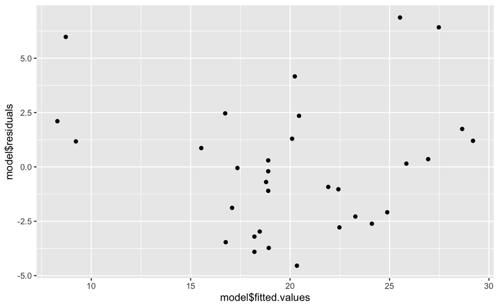

```r
model <- lm(mtcars$mpg ~ mtcars$wt)   # model predicting miles per gallon from weight of the car

ggplot() +
  geom_point(aes(x = model$fitted.values, y = model$residuals))
```

If we have several graphs in the document and would like to change the size for this one, we can do that as a chunk option. I also labeled the axes & added a title (you should always do this…)

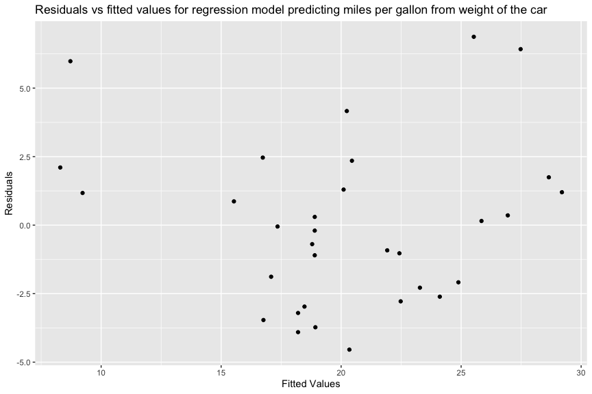

```r
ggplot() +
  geom_point(aes(x = model$fitted.values, y = model$residuals)) +
  ggtitle("Residuals vs fitted values for regression model predicting miles per gallon from weight of the car") +
  xlab("Fitted Values") +
  ylab("Residuals")
```

## Global arguments

You can use a code chunk to set global options as follows:

````
\```{r include=FALSE}
knitr::opts_chunk$set(echo = TRUE)
\```
````

```
---
title: "Code Clean Up"
author: "Matthew Beckman"
date: "April 28, 2021"
output:
  html_notebook:
    fig_height: 4
    fig_width: 6
---
```

You can even impose a global formatting template by calling a separate file with a .css extension in the yaml header. Then if you want to change the formatting template, all you have to do is switch the .css file!

## Knitting to other document types

- pandoc is a “universal document converter” so you can convert the same Rmd document into many different output documents
- YAML (Yet Another Markup Language; YAML Ain’t Markup Language) is a human friendly data serialization standard for all programming languages
- The “yaml header” at the top of the document provides instructions that pandoc uses to render different document types.
- We’ll look at a simple example using the default RMarkdown template document.
  - If you click the arrow next to the “Knit” button and yarn ball, you can select the different document types
  - The gear next to knit allows you to configure global options for the document
  - based on what you choose for both of the above, some code will show up in your yaml header to pass those instructions to pandoc for next time!
- You’ll need to have a LaTeX engine installed to render the PDF document types
  - In the “bad old days” this used to be a fairly significant configuration headache, but now it’s two lines of code that you only run one time in the console…

```
install.packages("tinytex")
tinytex::install_tinytex()
```